# Conditional Inference for Repeated Measures models

Livio Finos

# Permutation tests

## (minimal) Bibliography

The Theory:

- Pesarin (2001) Multivariate Permutation Tests: With Applications in Biostatistics, Wiley, New York
- Lehmann, E. L., & Romano, J. P. (2006). Testing statistical hypotheses. Springer.
- An alternative view to the Permutation testing: Hemerik J, Goeman J. Exact testing with random permutations. Test (Madr). 2018;27(4):811-825. doi: 10.1007/s11749-017-0571-1. Epub 2017 Nov 30. PMID: 30930620; PMCID: PMC6405018.

## A tutorial (my)

Based on R package `flip`: https://github.com/livioivil/flip and on CRAN

- html
- Rmd
- pdf

Other Packages:  
- permuco https://cran.r-project.org/web/packages/permuco/index.html  
- permute https://cran.r-project.org/web/packages/permute/index.html

# Permutation Testing with Repeated Measures

## Random coefficient Analysis / Group-level analysis

Again, using the R `flip` package: https://github.com/livioivil/flip and on CRAN

- html
- Rmd
- pdf

### (minimal) Bibliography

- Basso & Finos (2012). Exact Multivariate Permutation Tests for Fixed Effects in Mixed-Models. *Communications in Statistics - Theory and Methods*, 41: 2991 - 3001.
- Finos & Basso (2014) Permutation tests for between-unit fixed effects in multivariate generalized linear mixed models. *Stat Comput* 24, 941–952.

### Why is it cool? you don’t estimate the Fisher Information (i.e. the residual variance), an example with paired t-test

```r
n=20
y=rnorm(n)

FLIPS=flipscores:::.make_flips(n,1000)
head(FLIPS)
```

```
##      [,1] [,2] [,3] [,4] [,5] [,6] [,7] [,8] [,9] [,10] [,11] [,12] [,13] [,14]
## [1,]   -1   -1    1    1   -1   -1    1    1   -1     1    -1     1     1    -1
## [2,]    1   -1    1   -1    1    1   -1   -1    1     1    -1     1     1    -1
## [3,]   -1   -1   -1   -1    1   -1   -1   -1   -1    -1     1     1    -1    -1
## [4,]    1    1   -1   -1    1   -1    1   -1    1     1    -1    -1    -1     1
## [5,]    1    1   -1    1   -1   -1    1   -1    1    -1     1     1     1     1
## [6,]   -1   -1   -1    1   -1    1   -1    1   -1    -1     1    -1    -1     1
##      [,15] [,16] [,17] [,18] [,19] [,20]
## [1,]    -1    -1    -1    -1    -1     1
## [2,]    -1     1     1     1     1     1
## [3,]    -1    -1     1     1    -1     1
## [4,]    -1    -1     1     1     1    -1
## [5,]    -1     1    -1     1    -1    -1
## [6,]    -1     1    -1     1     1    -1
```

```r
Tstat=FLIPS%*%y
flipscores:::.t2p(Tstat)
```

```
## [1] 0.5
```

```r
MCMC=10000
Y=matrix(rnorm(n*MCMC),n,MCMC)
Tstat=FLIPS%*%Y
p.values=apply(Tstat,2,flipscores:::.t2p)
mean(p.values<.05)
```

```
## [1] 0.0485
```

```r
#########
t.test.light <- function(Y,tail=1){
  sd=apply(Y,2,sd,na.rm=TRUE)
  n=nrow(Y)
  ts= colMeans(Y,na.rm=TRUE)/sd*sqrt(n)
  pt(-ts,df = n-1)
}
###########

Y=replicate(MCMC,rnorm(n,sd = exp(1:n)))
Tstat=FLIPS%*%Y
p.values=apply(Tstat,2,flipscores:::.t2p)
p.values_param=t.test.light(Y)
mean(p.values<.05)
```

```
## [1] 0.0528
```

```r
mean(p.values_param<.05)
```

```
## [1] 0.0073
```

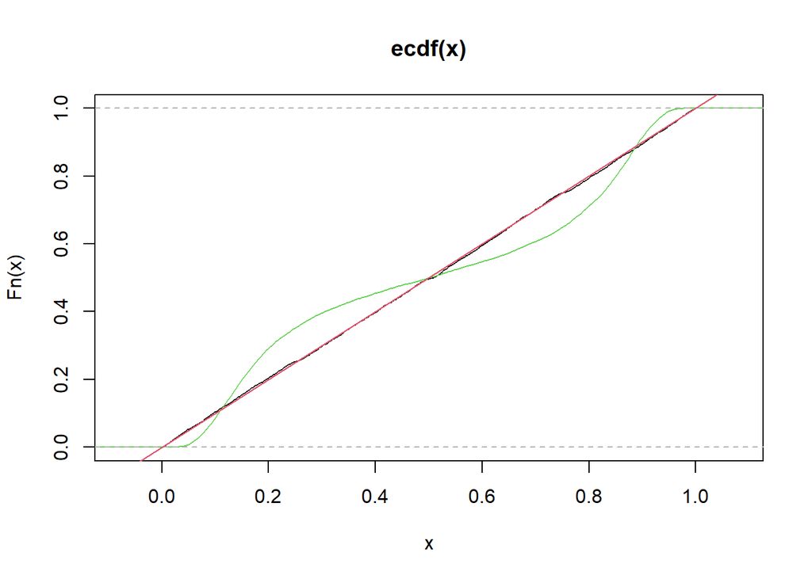

```r
plot.ecdf(p.values);plot.ecdf(p.values_param,add=TRUE,col=3);abline(0,1,col=2)
```

## An alternative approach

It generalizes the repeated measures approach to ubalanced designs. it is more model-based, it is less robust.

- Kherad-Pajouh, S., & Renaud, O. (2015). A general permutation approach for analyzing repeated measures ANOVA and mixed-model designs. Statistical Papers, 56(4), 947-967.
- Frossard, J. (2019). Permutation tests and multiple comparisons in the linear models and mixed linear models, with extension to experiments using electroencephalography. DOI: 10.13097/archive-ouverte/unige:125617.
- Frossard, J. & O. Renaud (2018). Permuco: Permutation Tests for Regression, (Repeated Measures) ANOVA/ANCOVA and Comparison of Signals. R Packages.

## Remarks

None of the two approaches above allow to deal with crossed random effects (e.g. subjects and stimuli). The problem is neglected in practice, while it is of vital importance. I’m working on it (with limited and frustrating results).

# Testing with Covariates (confounders)

## Linear model

Based on my favorite approach:

- [(theory) pdf](https://github.com/livioivil/inference_basics/blob/master/perm_covariates_22.pdf)
- [(a Lab) html](https://htmlpreview.github.io/?https://github.com/livioivil/inference_basics/blob/master/perm_covariates_Lab.html)
- [(a Lab) Rmd](https://github.com/livioivil/inference_basics/blob/master/perm_covariates_Lab.Rmd)
- (A nice review of the regression model within the permutation framework)  
  Anderson M. Winkler, Gerard R. Ridgway, Matthew A. Webster, Stephen M. Smith, Thomas E. Nichols (2014) Permutation inference for the general linear model, NeuroImage, Volume 92, Pages 381-397, ISSN 1053-8119 https://doi.org/10.1016/j.neuroimage.2014.01.060

## `flipscores`: A flexible and robust approach to General Linear Model

- Hemerik, Goeman and Finos (2020) Robust testing in generalized linear models by sign flipping score contributions. Journal of the Royal Statistical Society Series B (Statistical Methodology) 82(3). DOI: 10.1111/rssb.12369
- [Some slides to present the method](https://github.com/livioivil/livioivil.github.io/blob/master/talks/flipscores.pdf)

Implemented in R package `flipscores`:  
https://cran.r-project.org/web/packages/flipscores/index.html  
better to use the github developer version:  
https://github.com/livioivil/flipscores

# Multivariate (here specially fMRI and EEG kind of data)

- Nichols & Holmes (2001) Nonparametric Permutation Tests For Functional Neuroimaging: A Primer with Examples. *Human Brain Mapping* 15, 1-25. https://onlinelibrary.wiley.com/doi/ftr/10.1002/hbm.1058
- Se volete vedere un tutorial in R di Angela Andreella : https://angeella.github.io/Tutorials/pARIEEG.html nel tutorial tra l’altro lei presenta un suo lavoro con il quale supera la cluster-level analysis (Lower confidence bound of the true discovery proportion): A Andreella, J Hemerik, L Finos, W Weeda, J Goeman (2023) Permutation‐based true discovery proportions for functional magnetic resonance imaging cluster analysis. Statistics in Medicine